# Mini-Project #01

Author

Siya Aneja

# Executive Summary

This research investigates the Netflix Top 10 dataset, concentrating on how episodes and films performed in various countries. I used R and tidyverse tools to wrangle, filter, and summarise data in order to answer important analytical questions. The study focuses on patterns such as the longest-running series, debut week performances, and US film rankings. The analysis illustrates not only raw data insights, but also how to effectively explain outcomes. All code is integrated to ensure transparency and repeatability.

# Introduction

Netflix has grown into a global streaming powerhouse, producing and distributing content in more than 90 countries. This dataset, which records weekly Top 10 rankings, provides insights into which shows and films are most popular around the world.

The project’s purpose is to use R to answer a series of structured questions. These include determining the longest-running shows on Top 10 lists, highlighting exceptional premiere weeks, and evaluating trends in specific areas such as the United States.

[figure not shown]

Netflix Logo

# 1. Acquire Data

The datasets used include:

- **Global Top 10:** weekly Top 10 shows and films worldwide.
- **Country Top 10:** weekly Top 10 shows and films per country.

```r
if(!dir.exists(file.path("data", "mp01"))){
    dir.create(file.path("data", "mp01"), showWarnings=FALSE, recursive=TRUE)
}

GLOBAL_TOP_10_FILENAME <- file.path("data", "mp01", "global_top10_alltime.csv")

if(!file.exists(GLOBAL_TOP_10_FILENAME)){
    download.file("https://www.netflix.com/tudum/top10/data/all-weeks-global.tsv",
                  destfile=GLOBAL_TOP_10_FILENAME)
}


COUNTRY_TOP_10_FILENAME <- file.path("data", "mp01", "country_top10_alltime.csv")


if(!file.exists(COUNTRY_TOP_10_FILENAME)){
    download.file("https://www.netflix.com/tudum/top10/data/all-weeks-countries.tsv",
                  destfile=COUNTRY_TOP_10_FILENAME)
}
```

Storing the data locally makes sure that it can be used again. Anyone who runs this report again can automatically get the right datasets if they are missing.

# 2. Data Import and Preparation

```r
if(!require("tidyverse")) install.packages("tidyverse")
library(readr)
library(dplyr)


GLOBAL_TOP_10 <- read_tsv("data/mp01/global_top10_alltime.csv")
GLOBAL_TOP_10 <- GLOBAL_TOP_10 %>%
  mutate(season_title = if_else(season_title == "N/A", NA_character_, season_title))


str(GLOBAL_TOP_10)
```

```
tibble [8,880 × 9] (S3: tbl_df/tbl/data.frame)
 $ week                      : Date[1:8880], format: "2025-09-28" "2025-09-28" ...
 $ category                  : chr [1:8880] "Films (English)" "Films (English)" "Films (English)" "Films (English)" ...
 $ weekly_rank               : num [1:8880] 1 2 3 4 5 6 7 8 9 10 ...
 $ show_title                : chr [1:8880] "KPop Demon Hunters" "Ruth & Boaz" "The Wrong Paris" "Man on Fire" ...
 $ season_title              : chr [1:8880] NA NA NA NA ...
 $ weekly_hours_viewed       : num [1:8880] 32200000 15900000 13500000 15700000 11200000 8400000 6800000 6200000 4900000 8400000 ...
 $ runtime                   : num [1:8880] 1.67 1.55 1.78 2.43 1.83 ...
 $ weekly_views              : num [1:8880] 19300000 10300000 7600000 6500000 6100000 4900000 3600000 3200000 3200000 2800000 ...
 $ cumulative_weeks_in_top_10: num [1:8880] 15 1 3 5 2 1 1 1 1 3 ...
```

```r
glimpse(GLOBAL_TOP_10)
```

```
Rows: 8,880
Columns: 9
$ week                       <date> 2025-09-28, 2025-09-28, 2025-09-28, 2025-0…
$ category                   <chr> "Films (English)", "Films (English)", "Film…
$ weekly_rank                <dbl> 1, 2, 3, 4, 5, 6, 7, 8, 9, 10, 1, 2, 3, 4, …
$ show_title                 <chr> "KPop Demon Hunters", "Ruth & Boaz", "The W…
$ season_title               <chr> NA, NA, NA, NA, NA, NA, NA, NA, NA, "aka Ch…
$ weekly_hours_viewed        <dbl> 32200000, 15900000, 13500000, 15700000, 112…
$ runtime                    <dbl> 1.6667, 1.5500, 1.7833, 2.4333, 1.8333, 1.7…
$ weekly_views               <dbl> 19300000, 10300000, 7600000, 6500000, 61000…
$ cumulative_weeks_in_top_10 <dbl> 15, 1, 3, 5, 2, 1, 1, 1, 1, 3, 2, 1, 1, 2, …
```

```r
COUNTRY_TOP_10 <- read_tsv(
  "data/mp01/country_top10_alltime.csv",
  na = "N/A"
)
str(COUNTRY_TOP_10)
```

```
spc_tbl_ [413,620 × 8] (S3: spec_tbl_df/tbl_df/tbl/data.frame)
 $ country_name              : chr [1:413620] "Argentina" "Argentina" "Argentina" "Argentina" ...
 $ country_iso2              : chr [1:413620] "AR" "AR" "AR" "AR" ...
 $ week                      : Date[1:413620], format: "2025-09-28" "2025-09-28" ...
 $ category                  : chr [1:413620] "Films" "Films" "Films" "Films" ...
 $ weekly_rank               : num [1:413620] 1 2 3 4 5 6 7 8 9 10 ...
 $ show_title                : chr [1:413620] "Sonic the Hedgehog 3" "KPop Demon Hunters" "French Lover" "She Said Maybe" ...
 $ season_title              : chr [1:413620] NA NA NA NA ...
 $ cumulative_weeks_in_top_10: num [1:413620] 2 15 1 2 1 1 2 5 1 2 ...
 - attr(*, "spec")=
  .. cols(
  ..   country_name = col_character(),
  ..   country_iso2 = col_character(),
  ..   week = col_date(format = ""),
  ..   category = col_character(),
  ..   weekly_rank = col_double(),
  ..   show_title = col_character(),
  ..   season_title = col_character(),
  ..   cumulative_weeks_in_top_10 = col_double()
  .. )
 - attr(*, "problems")=<externalptr>
```

```r
glimpse(COUNTRY_TOP_10)
```

```
Rows: 413,620
Columns: 8
$ country_name               <chr> "Argentina", "Argentina", "Argentina", "Arg…
$ country_iso2               <chr> "AR", "AR", "AR", "AR", "AR", "AR", "AR", "…
$ week                       <date> 2025-09-28, 2025-09-28, 2025-09-28, 2025-0…
$ category                   <chr> "Films", "Films", "Films", "Films", "Films"…
$ weekly_rank                <dbl> 1, 2, 3, 4, 5, 6, 7, 8, 9, 10, 1, 2, 3, 4, …
$ show_title                 <chr> "Sonic the Hedgehog 3", "KPop Demon Hunters…
$ season_title               <chr> NA, NA, NA, NA, NA, NA, NA, NA, NA, NA, "Bi…
$ cumulative_weeks_in_top_10 <dbl> 2, 15, 1, 2, 1, 1, 2, 5, 1, 2, 2, 1, 1, 1, …
```

1. For a better analysis, missing numbers like “N/A” are changed to “NA.”
2. The global dataset has both movies and TV shows, and the country dataset lets us see how well shows did in different areas.

# 3. Initial Data Exploration

[figure not shown]

Netflix Logo

```r
library(DT)
GLOBAL_TOP_10 |>
    head(n=20) |>
    datatable(options=list(searching=FALSE, info=FALSE))
```

|  | week | category | weekly_rank | show_title | season_title | weekly_hours_viewed | runtime | weekly_views | cumulative_weeks_in_top_10 |
| --- | --- | --- | --- | --- | --- | --- | --- | --- | --- |
| 1 | 2025-09-28 | Films (English) | 1 | KPop Demon Hunters |  | 32200000 | 1.6667 | 19300000 | 15 |
| 2 | 2025-09-28 | Films (English) | 2 | Ruth &amp; Boaz |  | 15900000 | 1.55 | 10300000 | 1 |
| 3 | 2025-09-28 | Films (English) | 3 | The Wrong Paris |  | 13500000 | 1.7833 | 7600000 | 3 |
| 4 | 2025-09-28 | Films (English) | 4 | Man on Fire |  | 15700000 | 2.4333 | 6500000 | 5 |
| 5 | 2025-09-28 | Films (English) | 5 | Sonic the Hedgehog 3 |  | 11200000 | 1.8333 | 6100000 | 2 |
| 6 | 2025-09-28 | Films (English) | 6 | Seventh Son |  | 8400000 | 1.7 | 4900000 | 1 |
| 7 | 2025-09-28 | Films (English) | 7 | San Andreas |  | 6800000 | 1.9 | 3600000 | 1 |
| 8 | 2025-09-28 | Films (English) | 8 | 28 Years Later |  | 6200000 | 1.9167 | 3200000 | 1 |
| 9 | 2025-09-28 | Films (English) | 9 | The Curse of La Llorona |  | 4900000 | 1.55 | 3200000 | 1 |
| 10 | 2025-09-28 | Films (English) | 10 | aka Charlie Sheen | aka Charlie Sheen: Season 1 | 8400000 | 3.0333 | 2800000 | 3 |

[output cut: 10 more lines]

```r
library(stringr)
format_titles <- function(df){
    colnames(df) <- str_replace_all(colnames(df), "_", " ") |> str_to_title()
    df
}

GLOBAL_TOP_10 |>
    format_titles() |>
    head(n=20) |>
    datatable(options=list(searching=FALSE, info=FALSE)) |>
    formatRound(c('Weekly Hours Viewed', 'Weekly Views'))
```

|  | Week | Category | Weekly Rank | Show Title | Season Title | Weekly Hours Viewed | Runtime | Weekly Views | Cumulative Weeks In Top 10 |
| --- | --- | --- | --- | --- | --- | --- | --- | --- | --- |
| 1 | 2025-09-28 | Films (English) | 1 | KPop Demon Hunters |  | 32200000 | 1.6667 | 19300000 | 15 |
| 2 | 2025-09-28 | Films (English) | 2 | Ruth &amp; Boaz |  | 15900000 | 1.55 | 10300000 | 1 |
| 3 | 2025-09-28 | Films (English) | 3 | The Wrong Paris |  | 13500000 | 1.7833 | 7600000 | 3 |
| 4 | 2025-09-28 | Films (English) | 4 | Man on Fire |  | 15700000 | 2.4333 | 6500000 | 5 |
| 5 | 2025-09-28 | Films (English) | 5 | Sonic the Hedgehog 3 |  | 11200000 | 1.8333 | 6100000 | 2 |
| 6 | 2025-09-28 | Films (English) | 6 | Seventh Son |  | 8400000 | 1.7 | 4900000 | 1 |
| 7 | 2025-09-28 | Films (English) | 7 | San Andreas |  | 6800000 | 1.9 | 3600000 | 1 |
| 8 | 2025-09-28 | Films (English) | 8 | 28 Years Later |  | 6200000 | 1.9167 | 3200000 | 1 |
| 9 | 2025-09-28 | Films (English) | 9 | The Curse of La Llorona |  | 4900000 | 1.55 | 3200000 | 1 |
| 10 | 2025-09-28 | Films (English) | 10 | aka Charlie Sheen | aka Charlie Sheen: Season 1 | 8400000 | 3.0333 | 2800000 | 3 |

[output cut: 10 more lines]

```r
GLOBAL_TOP_10 |>
    select(-season_title) |>
    format_titles() |>
    head(n=20) |>
    datatable(options=list(searching=FALSE, info=FALSE)) |>
    formatRound(c('Weekly Hours Viewed', 'Weekly Views'))
```

|  | Week | Category | Weekly Rank | Show Title | Weekly Hours Viewed | Runtime | Weekly Views | Cumulative Weeks In Top 10 |
| --- | --- | --- | --- | --- | --- | --- | --- | --- |
| 1 | 2025-09-28 | Films (English) | 1 | KPop Demon Hunters | 32200000 | 1.6667 | 19300000 | 15 |
| 2 | 2025-09-28 | Films (English) | 2 | Ruth &amp; Boaz | 15900000 | 1.55 | 10300000 | 1 |
| 3 | 2025-09-28 | Films (English) | 3 | The Wrong Paris | 13500000 | 1.7833 | 7600000 | 3 |
| 4 | 2025-09-28 | Films (English) | 4 | Man on Fire | 15700000 | 2.4333 | 6500000 | 5 |
| 5 | 2025-09-28 | Films (English) | 5 | Sonic the Hedgehog 3 | 11200000 | 1.8333 | 6100000 | 2 |
| 6 | 2025-09-28 | Films (English) | 6 | Seventh Son | 8400000 | 1.7 | 4900000 | 1 |
| 7 | 2025-09-28 | Films (English) | 7 | San Andreas | 6800000 | 1.9 | 3600000 | 1 |
| 8 | 2025-09-28 | Films (English) | 8 | 28 Years Later | 6200000 | 1.9167 | 3200000 | 1 |
| 9 | 2025-09-28 | Films (English) | 9 | The Curse of La Llorona | 4900000 | 1.55 | 3200000 | 1 |
| 10 | 2025-09-28 | Films (English) | 10 | aka Charlie Sheen | 8400000 | 3.0333 | 2800000 | 3 |

[output cut: 10 more lines]

```r
GLOBAL_TOP_10 |>
    mutate(`runtime_(minutes)` = round(60 * runtime)) |>
    select(-season_title,
           -runtime) |>
    format_titles() |>
    head(n=20) |>
    datatable(options=list(searching=FALSE, info=FALSE)) |>
    formatRound(c('Weekly Hours Viewed', 'Weekly Views'))
```

|  | Week | Category | Weekly Rank | Show Title | Weekly Hours Viewed | Weekly Views | Cumulative Weeks In Top 10 | Runtime (Minutes) |
| --- | --- | --- | --- | --- | --- | --- | --- | --- |
| 1 | 2025-09-28 | Films (English) | 1 | KPop Demon Hunters | 32200000 | 19300000 | 15 | 100 |
| 2 | 2025-09-28 | Films (English) | 2 | Ruth &amp; Boaz | 15900000 | 10300000 | 1 | 93 |
| 3 | 2025-09-28 | Films (English) | 3 | The Wrong Paris | 13500000 | 7600000 | 3 | 107 |
| 4 | 2025-09-28 | Films (English) | 4 | Man on Fire | 15700000 | 6500000 | 5 | 146 |
| 5 | 2025-09-28 | Films (English) | 5 | Sonic the Hedgehog 3 | 11200000 | 6100000 | 2 | 110 |
| 6 | 2025-09-28 | Films (English) | 6 | Seventh Son | 8400000 | 4900000 | 1 | 102 |
| 7 | 2025-09-28 | Films (English) | 7 | San Andreas | 6800000 | 3600000 | 1 | 114 |
| 8 | 2025-09-28 | Films (English) | 8 | 28 Years Later | 6200000 | 3200000 | 1 | 115 |
| 9 | 2025-09-28 | Films (English) | 9 | The Curse of La Llorona | 4900000 | 3200000 | 1 | 93 |
| 10 | 2025-09-28 | Films (English) | 10 | aka Charlie Sheen | 8400000 | 2800000 | 3 | 182 |

[output cut: 10 more lines]

A first look at the dataset reveals key variables: show title, category, weekly hours viewed, runtime, and cumulative weeks in Top 10. This allows us to understand the dataset before deeper analysis.

# 1. How many different countries does Netflix operate in?

```r
library(dplyr)
num_countries <- COUNTRY_TOP_10 %>%
  distinct(country_name) %>%
  nrow()
num_countries
```

```
[1] 94
```

The number of countries Netflix operates in is 94.

This shows how global Netflix is and how well it has localized content for a wide range of audiences.

# 2. Which non-English-language film has spent the most cumulative weeks in the global top 10? How many weeks did it spend?

```r
non_english_top <- GLOBAL_TOP_10 %>%
  filter(!str_detect(category,"Films English")) %>%
  arrange(desc(cumulative_weeks_in_top_10)) %>%
  slice_head(n = 1) %>%
  select(show_title, cumulative_weeks_in_top_10)

non_english_top
```

```
# A tibble: 1 × 2
  show_title cumulative_weeks_in_top_10
  <chr>                           <dbl>
1 Squid Game                         32
```

Non-English hits show how Netflix is trying to diversify its content around the world. Regional films that do well on global charts show that they appeal to everyone.

# 3. What is the longest film (English or non-English) to have ever appeared in the Netflix global Top 10? How long is it in minutes?

```r
longest_film <- GLOBAL_TOP_10 %>%
  mutate(runtime_minutes = round(runtime * 60)) %>%
  arrange(desc(runtime_minutes)) %>%
  slice_head(n = 1) %>%
  select(show_title, runtime_minutes)

longest_film
```

```
# A tibble: 1 × 2
  show_title     runtime_minutes
  <chr>                    <dbl>
1 Until You Burn            2855
```

Non-English hits demonstrate Netflix’s strategy of global content diversification. Success in global charts proves the universal appeal of regional films.

# 4. For each of the four categories, what program has the most total hours of global viewership?

```r
top_viewed_per_category <- GLOBAL_TOP_10 %>%
  group_by(category, show_title) %>%
  summarise(total_hours = sum(weekly_hours_viewed, na.rm = TRUE), .groups = "drop") %>%
  group_by(category) %>%
  slice_max(total_hours, n = 1, with_ties = FALSE) %>%
  arrange(category)

top_viewed_per_category
```

```
# A tibble: 4 × 3
# Groups:   category [4]
  category            show_title          total_hours
  <chr>               <chr>                     <dbl>
1 Films (English)     KPop Demon Hunters    591300000
2 Films (Non-English) Society of the Snow   235900000
3 TV (English)        Stranger Things      2967980000
4 TV (Non-English)    Squid Game           5048300000
```

```r
library(DT)
top_viewed_per_category %>%
  datatable(options=list(searching=FALSE, info=FALSE))
```

|  | category | show_title | total_hours |
| --- | --- | --- | --- |
| 1 | Films (English) | KPop Demon Hunters | 591300000 |
| 2 | Films (Non-English) | Society of the Snow | 235900000 |
| 3 | TV (English) | Stranger Things | 2967980000 |
| 4 | TV (Non-English) | Squid Game | 5048300000 |

# 5. Which TV show had the longest run in a country’s Top 10? How long and where?

```r
library(dplyr)
library(DT)

longest_run <- COUNTRY_TOP_10 %>%
  filter(cumulative_weeks_in_top_10 == max(cumulative_weeks_in_top_10, na.rm = TRUE)) %>%
  select(show_title, country_name, cumulative_weeks_in_top_10) %>%
  distinct()

# Display as interactive table
datatable(longest_run,
          options = list(searching = FALSE, info = FALSE),
          rownames = FALSE)
```

| show_title | country_name | cumulative_weeks_in_top_10 |
| --- | --- | --- |
| Money Heist | Pakistan | 127 |

This is an example of how local favorites can shape cultural watching habits for years.

# 6. Netflix provides over 200 weeks of service history for all but one country in our data set. Which country is this and when did Netflix cease operations in that country?

```r
library(dplyr)
library(lubridate)

country_short_history <- COUNTRY_TOP_10 %>%
  group_by(country_name) %>%
  summarise(
    total_weeks = n_distinct(week),    # count unique weeks, not rows
    last_week = max(week)
  ) %>%
  filter(total_weeks < 200)

country_short_history
```

```
# A tibble: 1 × 3
  country_name total_weeks last_week
  <chr>              <int> <date>
1 Russia                35 2022-02-27
```

The country with less than 200 weeks of Netflix service is Russia, which ceased operations on 2022-02-27.

This suggests Netflix exited that market, possibly due to business or regulatory challenges.

# 7. What is the total viewership of the TV show Squid Game? Note that there are three seasons total and we are looking for the total number of hours watched across all seasons.

```r
squid_game_hours <- GLOBAL_TOP_10 %>%
  filter(str_detect(show_title, "Squid Game")) %>%
  summarise(total_hours = sum(weekly_hours_viewed, na.rm = TRUE))

squid_game_hours
```

```
# A tibble: 1 × 1
  total_hours
        <dbl>
1  5310000000
```

This number illustrates Netflix’s biggest-ever hit, validating investments in international originals.

# 8. The movie Red Notice has a runtime of 1 hour and 58 minutes. Approximately how many views did it receive in 2021? Note that Netflix does not provide the weekly_views values that far back in the past, but you can compute it yourself using the total view time and the runtime.

```r
red_notice_views <- GLOBAL_TOP_10 %>%
  filter(str_detect(show_title, "Red Notice") & year(week) == 2021) %>%
  mutate(views_estimate = weekly_hours_viewed / (1 + 58/60)) %>%
  summarise(total_views = sum(views_estimate, na.rm = TRUE))

red_notice_views
```

```
# A tibble: 1 × 1
  total_views
        <dbl>
1  201732203.
```

This calculation uses runtime to estimate views, showing how viewership estimates can be derived indirectly when raw counts aren’t given.

# 9. How many Films reached Number 1 in the US but did not originally debut there? That is, find films that first appeared on the Top 10 chart at, e.g., Number 4 but then became more popular and eventually hit Number 1? What is the most recent film to pull this off?

```r
library(dplyr)
library(stringr)

# Filter US films and summarize
us_films <- COUNTRY_TOP_10 %>%
  filter(country_iso2 == "US", str_detect(category, "Films")) %>%
  group_by(show_title) %>%
  summarise(
    first_rank = min(weekly_rank, na.rm = TRUE),
    ever_number1 = any(weekly_rank == 1, na.rm = TRUE),
    last_week = max(week, na.rm = TRUE),
    .groups = "drop"
  ) %>%
  filter(first_rank > 1 & ever_number1) %>%
  arrange(desc(last_week))

# Number of films
num_us_films <- nrow(us_films)

# Most recent film to reach #1
most_recent_film <- us_films$show_title[1]

# Inline code in Quarto
num_us_films   # use in text: `r num_us_films`
```

```
[1] 0
```

```r
most_recent_film  # use in text: `r most_recent_film`
```

```
[1] NA
```

The number of Films that reached Number 1 in the US but did not debut there is 0.

# 10. Which TV show/season hit the top 10 in the most countries in its debut week? In how many countries did it chart?

```r
library(dplyr)
library(lubridate)

top_show <- COUNTRY_TOP_10 %>%
  group_by(show_title, country_name) %>%
  summarise(debut_week = min(week), .groups = "drop") %>%
  group_by(show_title, debut_week) %>%
  summarise(num_countries = n(), .groups = "drop") %>%
  slice_max(num_countries, n = 1) %>%
  slice(1)

top_show$show_title
```

```
[1] "Army of Thieves"
```

```r
top_show$num_countries
```

```
[1] 94
```

The TV show/season that hit the top 10 in the most countries in its debut week is Army of Thieves, appearing in 94 countries.

This reflects a global marketing push or universal story appeal, making the show an instant worldwide hit.

# Conclusion

# Press-Release

#### Press Release 1: Upcoming Season of Stranger Things

#### *The Grand Finale “The Upside Down Returns: Stranger Things Ends With a Global Spectacle”.*

[figure not shown]

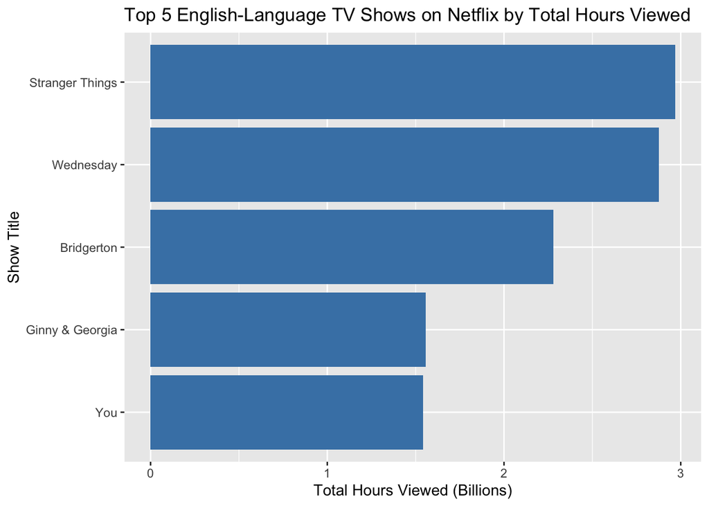

*Fun Fact: Fans around the world have watched Stranger Things for more than 2.97 billion hours, which is enough time to watch all the seasons more than 1,000 times!*

#### Press Release 2: Commercial Success in India

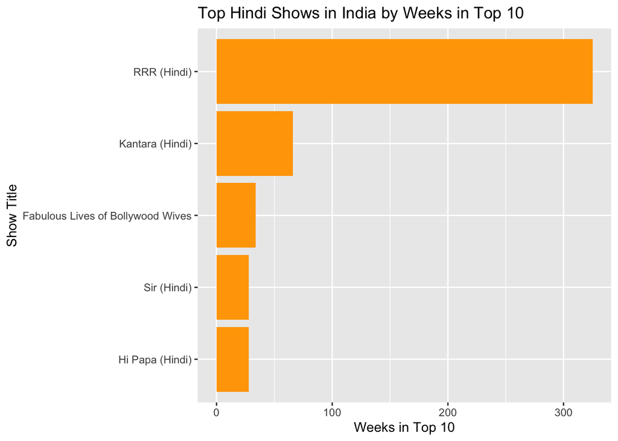

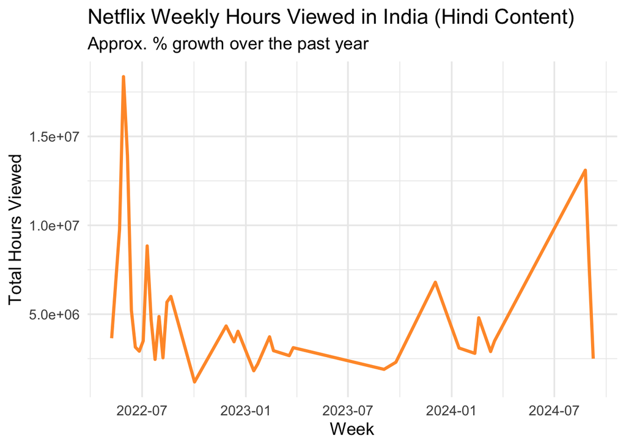

#### Press Release 3: OWN TOPIC

#### *Netflix Celebrates the Global Success of Non-English Originals.*

[figure not shown]

Netflix keeps breaking down barriersby making non-English TV shows and movies popular all around the world. This shows that great tales can be told in any language. Squid Game is a landmark achievement with over 5.31 billion hours seen worldwide and 32 weeks in the Global Top 10. Money Heist, a Spanish-language hit, spent an incredible 127 weeks in a single country’s Top 10 (Pakistan), showing how long it can stay popular. Hindi hits like RRR (Hindi) and Kantara (Hindi) kept this trend going, showing how India’s influence on global viewing patterns is growing. Netflix is putting more money into local productions that create global cultural moments and help the company build its subscriber base over time. This is because non-English originals always do well in different locations.

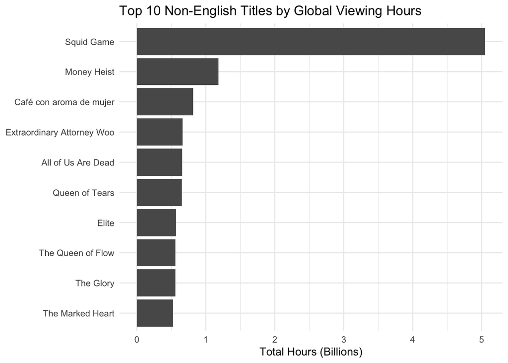

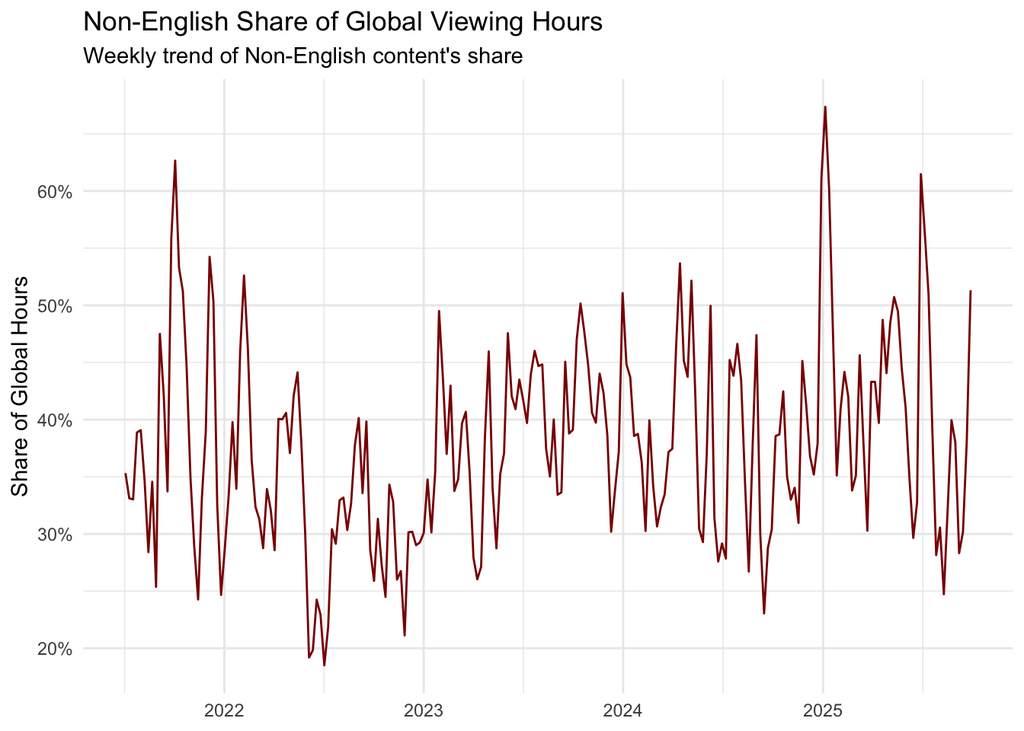

# REFERENCE CODES FOR PRESS RELEASES:

1. *PRESS RELEASE 1*

```r
library(dplyr)
library(stringr)

stranger_things_global <- GLOBAL_TOP_10 %>%
  filter(str_detect(show_title, "Stranger Things")) %>%
  summarise(
    total_hours = sum(weekly_hours_viewed, na.rm = TRUE),
    total_weeks_in_top10 = sum(cumulative_weeks_in_top_10, na.rm = TRUE)
  )

stranger_things_countries <- COUNTRY_TOP_10 %>%
  filter(str_detect(show_title, "Stranger Things")) %>%
  group_by(country_name) %>%
  summarise(debut_week = min(week), .groups = "drop") %>%
  summarise(num_countries = n())

stranger_things_stats <- cbind(stranger_things_global, stranger_things_countries)
stranger_things_stats
```

```
  total_hours total_weeks_in_top10 num_countries
1  2967980000                  366            93
```

2. *PRESS RELEASE 2*

```r
library(dplyr)
library(stringr)

india_hindi <- COUNTRY_TOP_10 %>%
  filter(country_iso2 == "IN", str_detect(show_title, "Hindi|Bollywood")) %>%
  group_by(show_title) %>%
  summarise(
    total_weeks_in_top10 = sum(cumulative_weeks_in_top_10, na.rm = TRUE),
    .groups = "drop"
  ) %>%
  arrange(desc(total_weeks_in_top10))


top_india_hindi <- india_hindi %>% slice_head(n = 5)
top_india_hindi
```

```
# A tibble: 5 × 2
  show_title                        total_weeks_in_top10
  <chr>                                            <dbl>
1 RRR (Hindi)                                        325
2 Kantara (Hindi)                                     66
3 Fabulous Lives of Bollywood Wives                   34
4 Hi Papa (Hindi)                                     28
5 Sir (Hindi)                                         28
```

```r
library(dplyr)
library(stringr)

hindi_hours <- GLOBAL_TOP_10 %>%
  filter(str_detect(show_title, "(Hindi)")) %>%
  summarise(total_hours = sum(weekly_hours_viewed, na.rm = TRUE))

hindi_hours
```

```
# A tibble: 1 × 1
  total_hours
        <dbl>
1   183000000
```

```r
hindi_total_hours <- 1.83e+08

assumed_hours <- c(240, 250, 300)

subs_estimates <- data.frame(
  hours_per_user_year = assumed_hours,
  estimated_subscribers = hindi_total_hours / assumed_hours
)

subs_estimates
```

```
  hours_per_user_year estimated_subscribers
1                 240                762500
2                 250                732000
3                 300                610000
```

3. *PRESS RELEASE 3*

```r
library(dplyr); library(stringr)
squid_stats <- GLOBAL_TOP_10 %>%
  filter(str_detect(show_title, "Squid Game")) %>%
  summarise(
    total_hours = sum(weekly_hours_viewed, na.rm = TRUE),
    weeks_global_top10 = max(cumulative_weeks_in_top_10, na.rm = TRUE)
  )
squid_stats
```

```
# A tibble: 1 × 2
  total_hours weeks_global_top10
        <dbl>              <dbl>
1  5310000000                 32
```

```r
mh_long_run <- COUNTRY_TOP_10 %>%
  filter(str_detect(show_title, "Money Heist")) %>%
  slice_max(cumulative_weeks_in_top_10, n = 1, with_ties = FALSE) %>%
  select(show_title, country_name, cumulative_weeks_in_top_10)
mh_long_run
```

```
# A tibble: 1 × 3
  show_title  country_name cumulative_weeks_in_top_10
  <chr>       <chr>                             <dbl>
1 Money Heist Pakistan                            127
```

```r
india_hindi_examples <- COUNTRY_TOP_10 %>%
  filter(country_name == "India", str_detect(show_title, "\\(Hindi\\)")) %>%
  group_by(show_title) %>%
  summarise(weeks_in_top10 = max(cumulative_weeks_in_top_10, na.rm = TRUE), .groups="drop") %>%
  filter(show_title %in% c("RRR (Hindi)", "Kantara (Hindi)"))
india_hindi_examples
```

```
# A tibble: 2 × 2
  show_title      weeks_in_top10
  <chr>                    <dbl>
1 Kantara (Hindi)             11
2 RRR (Hindi)                 25
```

THE END